# Protein (MAT Alpha-2 Transcriptional…

Fold-switch pair **1mnmD_1mnmC** — **1mnmD** vs **1mnmC**

Saccharomyces cerevisiae

## Figure 1: Phylogenetic tree with per-cluster fold-preference heatmap.

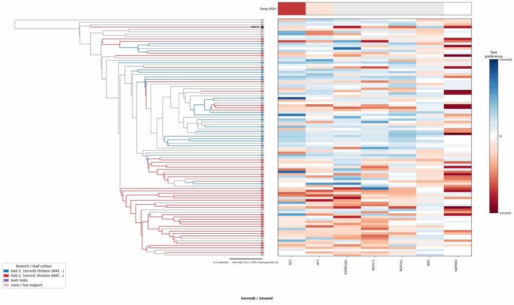

## Figure 2: Aligned overlay (both folds superposed)

The single fold-switching chain of each fold superposed by TM-align; waters hidden, any ligand shown as green sticks. Grey = structurally conserved core, colour = divergent (fold-switching) region.

1mnmD (Protein (MAT Alpha-2 Transcriptional…) · trimer1mnmC (Protein (MAT Alpha-2 Transcriptional…) · trimer

TM-score: 0.753 · Trigger class: equilibrium_or_unknown

Aligned overlay

Loading...

## Figure 3: The two folds, side by side

Each fold is coloured by per-residue Cα deviation between the two superposed structures: grey ≈ conserved core, full colour = structurally divergent (fold-switching) region.

1mnmD (Protein (MAT Alpha-2 Transcriptional…)

1mnmC (Protein (MAT Alpha-2 Transcriptional…)

0 Å5≥10 Å

1mnmD (Protein (MAT Alpha-2 Transcriptional…)

Loading...

1mnmC (Protein (MAT Alpha-2 Transcriptional…)

Loading...

## Figure 4: Best-cluster predicted contact maps over the two true folds.

Predicted contact maps (MSA-Transformer) for the clusters best matching each fold, over the true contacts of fold 1 (upper triangle) and fold 2 (lower). Divergent contacts between clusters are the contact-level signature of fold-switching.

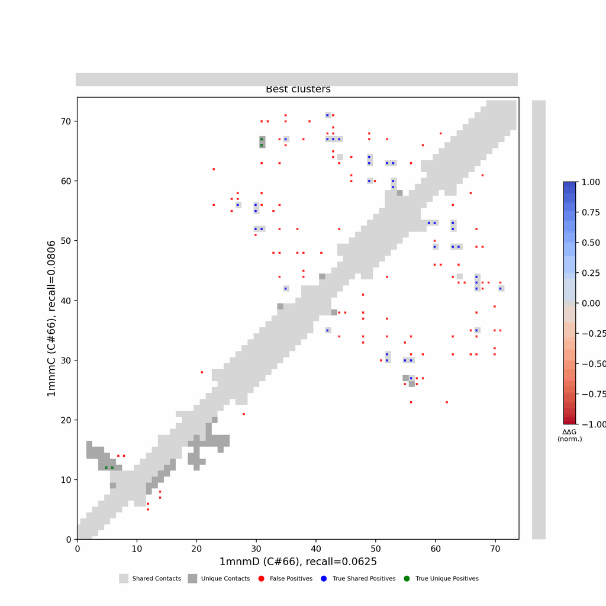

## Figure 5: Per-residue ΔΔG fold-preference contribution

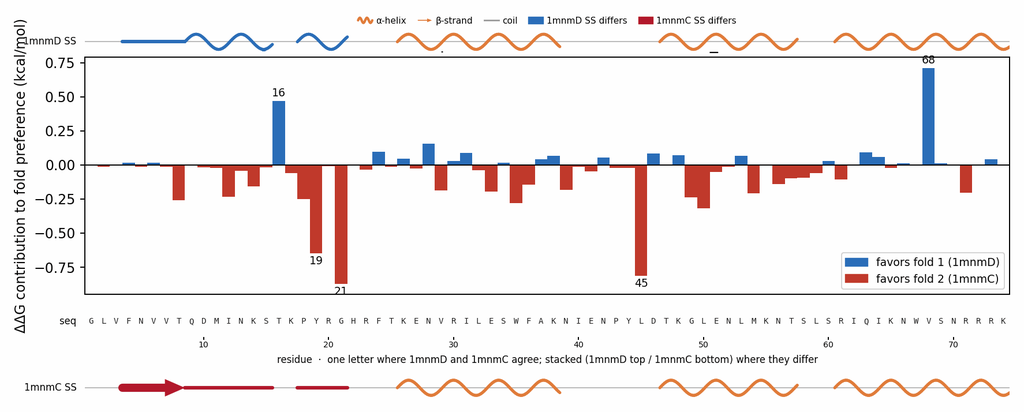

**More figures**

## Figure 6: Deep-MSA contact map panel / Best clusters contact map panel

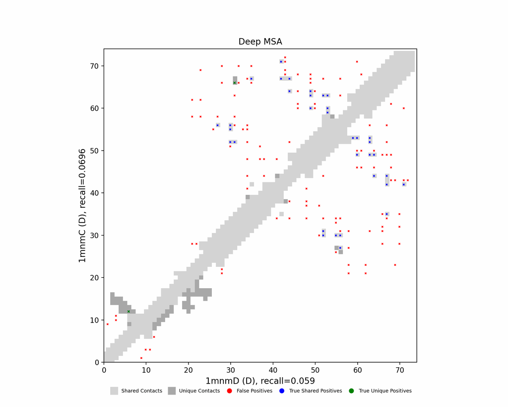

Deep-MSA contact map panel

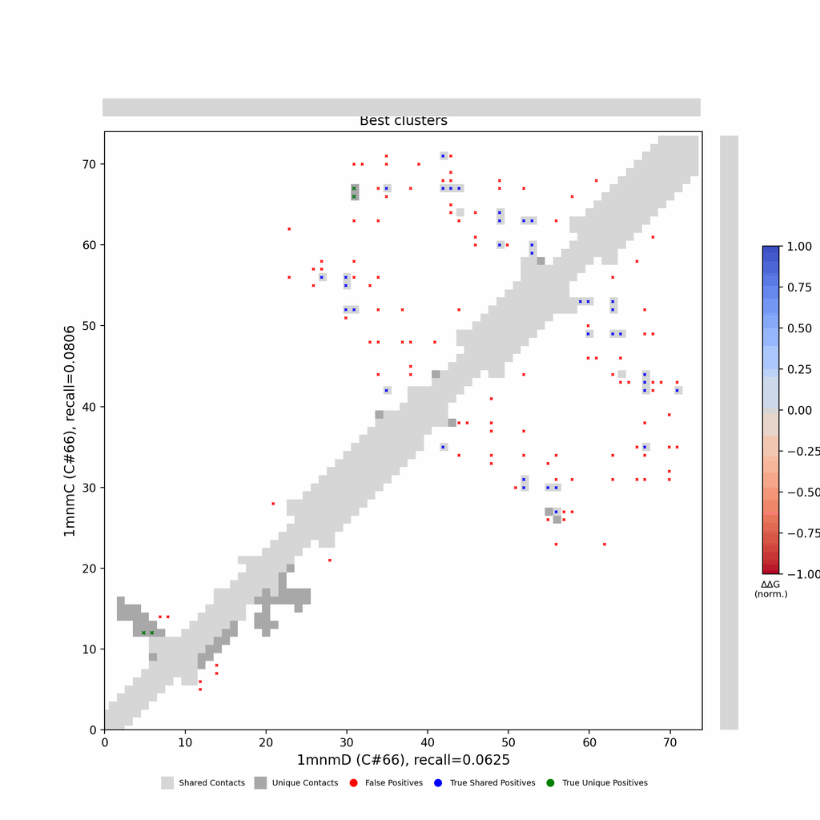

Best clusters contact map panel

## Figure 7: All clusters contact-map mosaic (small multiples).

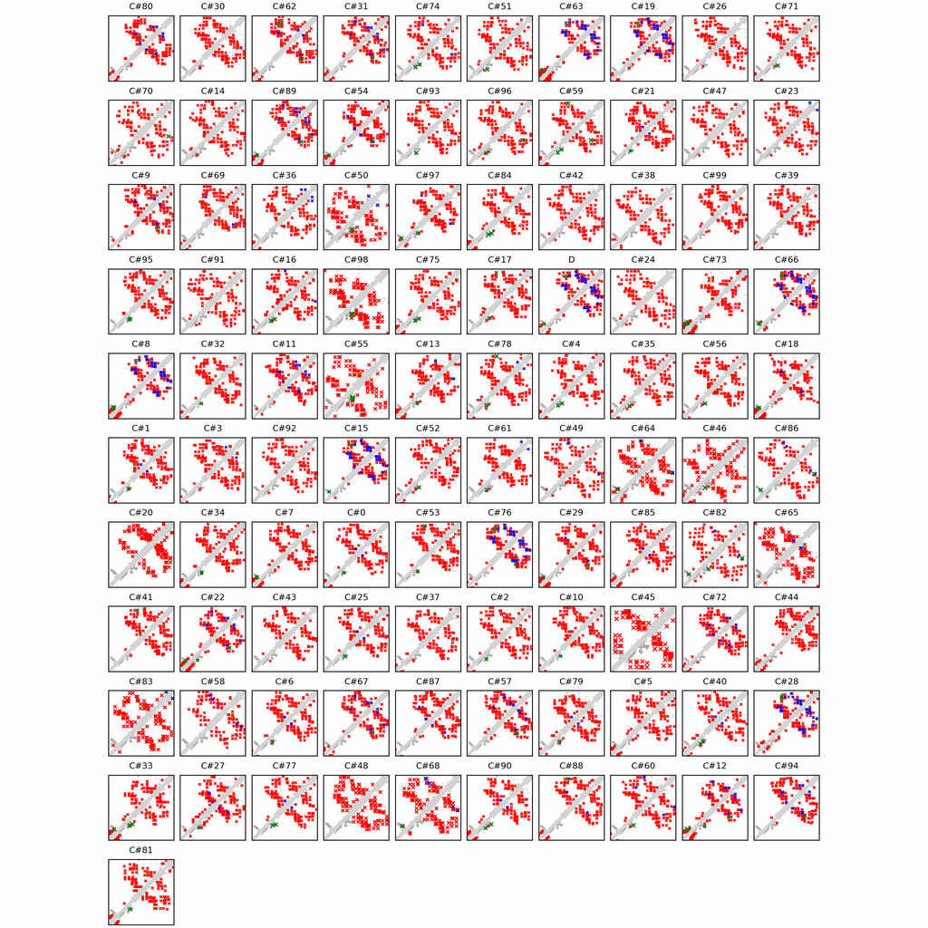

## Figure 8: Phylo null: tree with shuffled cluster fold labels.

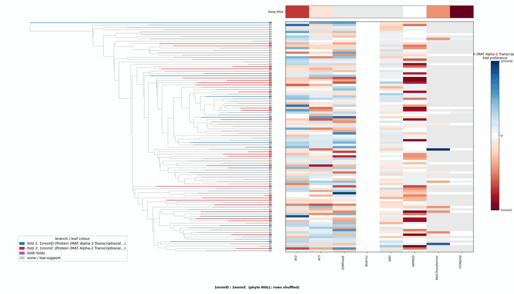

## Cluster metrics table

Per-cluster metrics underlying the figures above.

| cluster | n | neff | AF2_TM1 | AF2_TM2 | AF3_TM1 | AF3_TM2 | RE-MSAT-COM | RE-MSAT1 | RE-MSAT2 | ESM_SEQIDS | ESM_TM1 | ESM_TM2 | ΔΔG_Bias | ΔΔG_Bias_std | ΔΔG_frac_F1 | Boltz2_pref | S4PRED_pref | CCMpred_pref | BioEmu_pref |
| --- | --- | --- | --- | --- | --- | --- | --- | --- | --- | --- | --- | --- | --- | --- | --- | --- | --- | --- | --- |
| Deep | - | - | 0.72 | 0.75 | 0.71 | 0.72 | 0.48 | 0.38 | 0.4 | - | - | - | - | - | - | - | -0.0 | -0.02 | - |
| 000 | 471.0 | 324.0 | 0.6 | 0.6 | 0.59 | 0.6 | 0.03 | 0.05 | 0.02 | 001; 001; 004; 004; 009; 009; 002; 008; 008; 002 | 0.65 ± 0.03 | 0.66 ± 0.03 | -4.09 | 1.65 | 0.0 | -0.01 | 0.12 | 0.0 | -0.0 |
| 001 | 382.0 | 324.0 | 0.63 | 0.64 | 0.63 | 0.63 | 0.03 | 0.05 | 0.02 | 001; 001; 002; 002; 005; 005; 008; 008; 003; 003 | 0.66 ± 0.03 | 0.67 ± 0.03 | -4.42 | 2.06 | 0.1 | 0.0 | 0.07 | 0.0 | -0.0 |
| 002 | 251.0 | 193.0 | 0.59 | 0.6 | 0.54 | 0.54 | 0.0 | 0.0 | 0.0 | 002; 003; 003; 002; 001; 005; 001; 005; 004; 004 | 0.67 ± 0.03 | 0.68 ± 0.03 | -4.44 | 2.1 | 0.0 | -0.01 | 0.05 | 0.0 | -0.0 |
| 003 | 177.0 | 154.0 | 0.59 | 0.6 | 0.55 | 0.55 | 0.0 | 0.0 | 0.0 | 001; 002; 004; 002; 001; 004; 005; 005; 006; 006 | 0.66 ± 0.02 | 0.67 ± 0.02 | -4.69 | 2.21 | 0.0 | -0.0 | 0.12 | 0.0 | -0.0 |
| 004 | 173.0 | 116.0 | 0.61 | 0.63 | 0.58 | 0.58 | 0.0 | 0.0 | 0.0 | 010; 010; 004; 004; 005; 001; 005; 001; 003; 003 | 0.63 ± 0.01 | 0.66 ± 0.01 | -3.85 | 1.52 | 0.0 | -0.01 | -0.07 | 0.0 | -0.01 |
| 005 | 149.0 | 98.0 | 0.6 | 0.62 | 0.6 | 0.62 | 0.0 | 0.0 | 0.0 | 002; 001; 002; 001; 010; 010; 008; 008; 004; 003 | 0.65 ± 0.03 | 0.67 ± 0.03 | -3.62 | 1.87 | 0.0 | -0.03 | -0.07 | 0.0 | -0.02 |
| 006 | 142.0 | 122.0 | 0.59 | 0.59 | 0.55 | 0.55 | 0.03 | 0.05 | 0.03 | 010; 010; 009; 009; 001; 001; 006; 005; 002; 002 | 0.65 ± 0.01 | 0.67 ± 0.01 | -4.18 | 2.26 | 0.0 | 0.0 | 0.12 | 0.0 | 0.0 |
| 007 | 138.0 | 76.0 | 0.66 | 0.7 | 0.68 | 0.68 | 0.0 | 0.0 | 0.0 | 001; 005; 005; 001; 004; 008; 004; 008; 006; 006 | 0.67 ± 0.01 | 0.69 ± 0.02 | -5.14 | 1.34 | 0.0 | -0.0 | 0.12 | 0.0 | -0.01 |
| 008 | 119.0 | 97.0 | 0.66 | 0.67 | 0.6 | 0.61 | 0.47 | 0.37 | 0.39 | 008; 008; 001; 009; 007; 006; 009; 001; 007; 006 | 0.62 ± 0.00 | 0.65 ± 0.01 | -4.66 | 1.69 | 0.0 | -0.01 | 0.06 | 0.0 | -0.01 |
| 009 | 113.0 | 95.0 | 0.7 | 0.72 | 0.69 | 0.7 | 0.03 | 0.03 | 0.03 | 004; 004; 002; 002; 008; 008; 003; 003; 001; 001 | 0.68 ± 0.03 | 0.70 ± 0.03 | -4.12 | 2.14 | 0.0 | -0.0 | 0.12 | 0.0 | -0.01 |
| 010 | 110.0 | 95.0 | 0.59 | 0.61 | 0.59 | 0.61 | 0.0 | 0.0 | 0.0 | 006; 006; 001; 010; 008; 002; 002; 001; 010; 005 | 0.62 ± 0.01 | 0.65 ± 0.00 | -3.54 | 1.84 | 0.0 | -0.01 | 0.12 | 0.0 | -0.02 |
| 011 | 98.0 | 71.0 | 0.66 | 0.67 | 0.58 | 0.57 | 0.11 | 0.09 | 0.09 | 007; 007; 001; 001; 009; 009; 002; 002; 003; 003 | 0.67 ± 0.02 | 0.69 ± 0.04 | -4.65 | 2.72 | 0.1 | -0.01 | 0.06 | 0.0 | -0.01 |
| 012 | 97.0 | 68.0 | 0.6 | 0.63 | 0.6 | 0.64 | 0.12 | 0.1 | 0.09 | 010; 010; 003; 004; 004; 003; 002; 002; 007; 001 | 0.63 ± 0.00 | 0.65 ± 0.01 | -3.48 | 1.97 | 0.0 | -0.02 | -0.07 | 0.0 | -0.01 |
| 013 | 97.0 | 61.0 | 0.61 | 0.63 | 0.55 | 0.57 | 0.0 | 0.0 | 0.0 | 002; 002; 004; 004; 008; 008; 001; 005; 001; 005 | 0.67 ± 0.01 | 0.70 ± 0.02 | -2.85 | 1.65 | 0.0 | -0.03 | 0.12 | 0.0 | -0.01 |
| 014 | 87.0 | 82.0 | 0.7 | 0.72 | 0.69 | 0.7 | 0.0 | 0.0 | 0.0 | 004; 004; 005; 005; 002; 002; 003; 003; 001; 001 | 0.66 ± 0.03 | 0.67 ± 0.01 | -3.04 | 1.1 | 0.0 | -0.0 | 0.07 | 0.0 | -0.01 |
| 015 | 87.0 | 53.0 | 0.6 | 0.6 | 0.59 | 0.6 | 0.43 | 0.35 | 0.37 | 001; 001; 005; 005; 003; 010; 003; 010; 009; 008 | 0.64 ± 0.03 | 0.65 ± 0.05 | -3.78 | 1.76 | 0.0 | -0.0 | 0.11 | 0.0 | -0.0 |
| 016 | 86.0 | 49.0 | 0.4 | 0.4 | 0.37 | 0.37 | 0.04 | 0.06 | 0.03 | 006; 006; 008; 008; 010; 010; 007; 005; 007; 005 | 0.62 ± 0.02 | 0.64 ± 0.01 | -3.17 | 1.43 | 0.0 | -0.0 | -0.06 | 0.0 | -0.0 |
| 017 | 81.0 | 68.0 | 0.63 | 0.66 | 0.62 | 0.63 | 0.0 | 0.03 | 0.03 | 004; 005; 009; 005; 004; 009; 003; 003; 001; 002 | 0.62 ± 0.01 | 0.64 ± 0.01 | -4.62 | 1.88 | 0.0 | -0.02 | 0.12 | 0.0 | -0.01 |
| 018 | 81.0 | 57.0 | 0.61 | 0.63 | 0.59 | 0.64 | 0.05 | 0.04 | 0.04 | 006; 005; 006; 005; 010; 002; 010; 002; 009; 009 | 0.62 ± 0.01 | 0.65 ± 0.00 | -5.23 | 1.03 | 0.0 | -0.02 | 0.11 | 0.0 | -0.01 |
| 019 | 79.0 | 47.0 | 0.68 | 0.7 | 0.64 | 0.66 | 0.49 | 0.39 | 0.41 | 001; 001; 004; 004; 003; 010; 007; 003; 010; 007 | 0.64 ± 0.02 | 0.66 ± 0.01 | -3.74 | 1.44 | 0.0 | -0.03 | 0.12 | 0.0 | -0.02 |
| 020 | 72.0 | 59.0 | 0.42 | 0.42 | 0.44 | 0.43 | 0.0 | 0.0 | 0.0 | - | - | - | -3.09 | 1.45 | 0.0 | 0.0 | 0.01 | - | -0.0 |
| 021 | 71.0 | 58.0 | 0.54 | 0.54 | 0.54 | 0.54 | 0.04 | 0.03 | 0.03 | - | - | - | -4.65 | 1.39 | 0.0 | 0.0 | 0.08 | - | 0.0 |
| 022 | 71.0 | 54.0 | 0.62 | 0.66 | 0.61 | 0.64 | 0.12 | 0.12 | 0.09 | - | - | - | -3.51 | 0.92 | 0.0 | -0.02 | 0.12 | - | -0.02 |
| 023 | 70.0 | 45.0 | 0.64 | 0.67 | 0.65 | 0.66 | 0.0 | 0.0 | 0.0 | - | - | - | -3.8 | 1.88 | 0.1 | -0.0 | 0.02 | - | -0.01 |
| 024 | 68.0 | 54.0 | 0.63 | 0.65 | 0.6 | 0.62 | 0.0 | 0.0 | 0.0 | - | - | - | -3.49 | 1.22 | 0.0 | -0.02 | 0.12 | - | -0.01 |
| 025 | 67.0 | 61.0 | 0.71 | 0.74 | 0.71 | 0.73 | 0.03 | 0.05 | 0.02 | - | - | - | -3.86 | 1.21 | 0.0 | -0.01 | 0.12 | - | -0.01 |
| 026 | 67.0 | 48.0 | 0.63 | 0.65 | 0.63 | 0.66 | 0.0 | 0.0 | 0.0 | - | - | - | -3.92 | 1.61 | 0.0 | -0.02 | 0.12 | - | -0.01 |
| 027 | 66.0 | 42.0 | 0.63 | 0.64 | 0.62 | 0.64 | 0.0 | 0.0 | 0.0 | - | - | - | -3.81 | 1.65 | 0.0 | -0.02 | 0.03 | - | -0.01 |
| 028 | 65.0 | 45.0 | 0.69 | 0.72 | 0.72 | 0.73 | 0.44 | 0.35 | 0.37 | - | - | - | -1.95 | 1.1 | 0.0 | -0.02 | -0.05 | - | -0.02 |

[output cut: 71 more lines]